# Basic data selection and transformations using R

SIMP59: Data Selection and Visualisation VT25  
7.5 credits

nils.holmberg@iko.lu.se

## Presentation

- Nils Holmberg
- Computational  
  content analysis
- Cognitive  
  communication effects

[video not shown]

## Course literature

[figure not shown]

Wickham, Çetinkaya-Rundel, and Grolemund (2023)

[figure not shown]

Wilke (2019)

Watt and Naidoo (2025)

## Lecture overview

- Data analysis framework
- Data types
- Data frames
- Data structures
- `Selecting data`
- Importing data
- Subsetting data
- Research questions
- `Transforming data`
- Adding data
- Grouping data
- Reshaping data
- Exporting data frames
- Visualizing data

## Data analysis framework

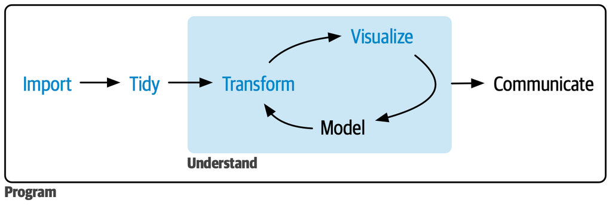

Figure 1: In this section of the book, you’ll learn how to import, tidy, transform, and visualize data.

## Open science communication

- **Replicability**: R enables reproducible research with shareable scripts.
- **Transparency**: Open-source code makes analyses fully visible.
- **Collaboration**: Supports teamwork via GitHub and R Markdown.
- **Open Source**: Free and community-driven for open science. 🚀

[figure not shown]